```python
import numpy as np
import matplotlib.pyplot as plt
from scipy.fft import idst
from sampler import pCN, MH, Gibbs, sampler
from hydraulic import hydraulic_class
from Matern_prior import Matern_prior
import arviz as az
from utils_plotting import posterior_stats_1D

measurement = np.load('measurement.npz')#N_points, x, X_true, p_true, noise_vec
N_points = measurement['N_points']
epsilons = measurement['noise_vec']
p_true = measurement['p_true']
X_true = measurement['X_true']
```

# Final exam project

In this project we construct the posteror for the hydraulic inverse problem, which follows an elliptical PDE $$ \frac{\partial}{\partial \xi}(\exp(\mathbf{X})\frac{\partial p_i}{\partial \xi}) = q_i \delta(\xi^i_\text{well}), \xi \in [0,1] $$

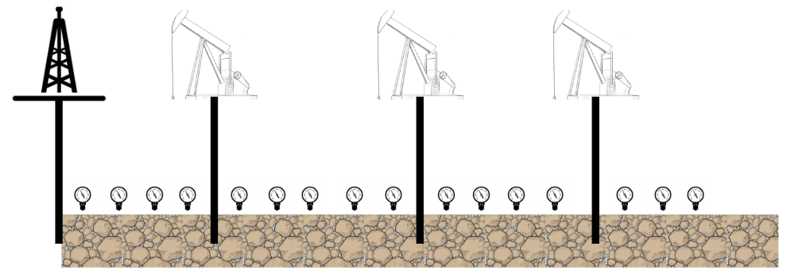

## 1 UQ of the hydraulic inverse problem

### a) Noise model

We let $G_i$ be the forward operator associated with the $i$ th injection. $$\mathbf{y}_\text{obs}^i = G_i(\mathbf{X}) + \varepsilon $$ where the noise follow the distribution $$ \varepsilon \sim \mathcal{N}(0,\sigma_\text{obs}^2 \mathbf{I}_N) $$

### b) Likelihood distribution

We consider the likelihood function

$$ \pi(\mathbf{y}_\text{obs}^1,\ldots,\mathbf{y}_\text{obs}^5 | \mathbf{X}) $$

which can be simplified by assuming that the individual measurements are independent. $$ \pi(\mathbf{y}_\text{obs}^1,\ldots,\mathbf{y}_\text{obs}^5 | \mathbf{X}) = \pi(\mathbf{y}_\text{obs}^1 | \mathbf{X}) \pi(\mathbf{y}_\text{obs}^2 | \mathbf{X}) \cdots \pi(\mathbf{y}_\text{obs}^5 | \mathbf{X}) $$ The individual likelihood function can be defined as a Gaussian distribution using the known mean (the forward model) and the known variance (from the noise). $$ \mathbf{y}_\text{obs}^i | \mathbf{X} \sim \mathcal{N}(G_i(\mathbf{X}),\sigma_\text{obs}^2 \mathbf{I}_N) $$ where the probalility density function explicitly can be written as proportional to $$ \pi(\mathbf{y}_\text{obs}^i | \mathbf{X}) \propto \exp\left(-\frac{||\mathbf{y}_\text{obs}^i - G_i(\mathbf{X})||_2^2}{2 \sigma_\text{obs}^2}\right) $$

### c) Matern prior

The Matern prior is a generalization of different types of Kernels.

$$ \mathbf{X} = m + \sum_i Z_i \left( \frac{1}{l^2} + i^2 \right)^{-(s+1/2)} \mathbf{e}_i $$

where $m$ is the mean, $Z_i$ is a random varable, $l$ is the correlation length, $s$ is the differentiability and $\mathbf{e}_i$ is the sine basis.

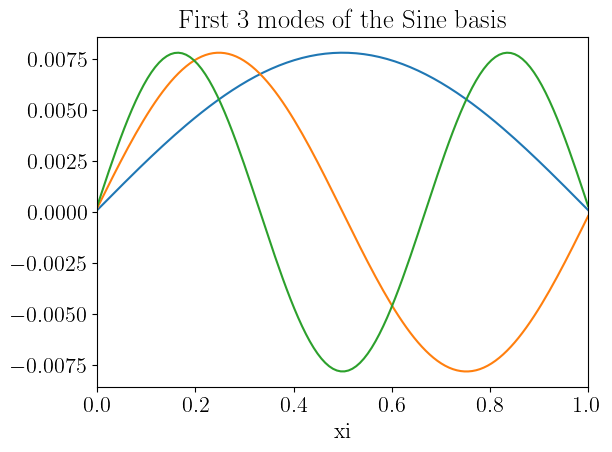

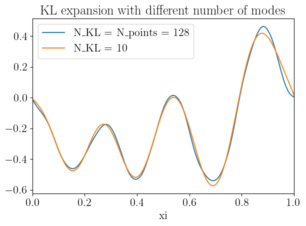

```python
s = 1.5
ell = 0.15
sigma = 0.4
N_KL = N_points
prior = Matern_prior(N_points,s,ell,sigma)
Z1 = np.random.randn(N_points)
Z2 = np.concatenate((Z1[:10], np.zeros(N_points-10)))
xi = np.linspace(0,1,N_points)
f,ax = plt.subplots()
ax.plot(xi,prior.f[:,:3])
ax.set_xlabel('xi')
ax.set_xlim((0,1))
ax.set_title('First 3 modes of the Sine basis')
f.tight_layout()

f,ax = plt.subplots()
ax.plot(xi,prior.assemble(Z1),label=f'N_KL = N_points = {N_points}')
ax.plot(xi,prior.assemble(Z2),label=f'N_KL = {10}')
ax.legend()
ax.set_xlabel('xi')
ax.set_xlim((0,1))
ax.set_title('KL expansion with different number of modes')
f.tight_layout()
```

### d) Implement likelihood with 5% noise

We begin by loading in the measurements in `measurement.npz`, which include the true pressures and true porosities.

```python
hydraulic = hydraulic_class(N_points)
```

We can use the true pressures to simulate a noisy signal with $d$% added noise. The noise level, $\sigma_\text{obs}$ should be dependent on the pressure magnitude, such that we can write noise term as

$$ \varepsilon = \frac{d}{100}||p_i||_{L_2}\frac{\epsilon}{||\epsilon||_2} $$

where $$ \epsilon \sim \mathcal{N}(0,1) $$ and the norm of $\epsilon$ has the the limit $$ ||\epsilon||_2 = \sqrt{N} $$ The standard deviation of the measurements are thus $$ \sigma_\text{obs}^i = \frac{d}{100}||p_i||_{L_2} \frac{1}{\sqrt{N}} $$

```
[0.0006951  0.00130149 0.00180846 0.00220259 0.00246472]
```

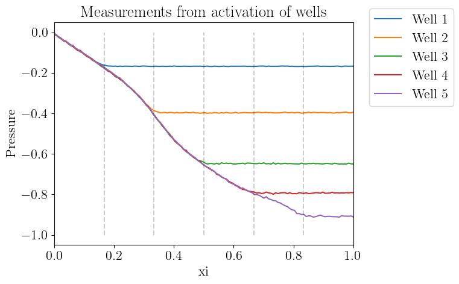

```python
def datamodel(noise=0.05):
    y_obs = []
    sigmas = []
    X = np.ones(N_KL)
    p = hydraulic.forward(X)
    dx = hydraulic.L/N_points
    # loop over injections
    for i in range(p_true.shape[0]):
        epsilon = np.random.randn(N_points)
        sig = noise*np.sqrt( np.sum( p[i,:]**2 * dx ) )   /np.sqrt(N_points)

        sigmas.append(sig)
        y_obs.append(p_true[i,:] + sig*epsilon)

    y_obs = np.array(y_obs)
    sigmas = np.array(sigmas)
    return y_obs,sigmas

wells = np.linspace(0,1,7)
wells = wells[1:-1]
y_obs, sigmas = datamodel(noise=0.05)
print(sigmas)

# plotting noisy measurement
f,ax = plt.subplots(1)
for i in range(p_true.shape[0]):
    ax.plot(xi,y_obs[i],label=f'Well {i+1}')
ax.plot(np.vstack((wells,wells)),np.vstack((np.ones(5)*-1,np.ones(5)*0)),'--k',alpha=0.2)
ax.set_xlabel('xi')
ax.set_xlim((0,1))
ax.set_ylabel('Pressure')
ax.set_title('Measurements from activation of wells')
f.legend(loc='upper center', bbox_to_anchor=(1.05, .95))
```

The log likelihood can be expresses as $$ \log \pi(\mathbf{y}_\text{obs}^1, \ldots, \mathbf{y}_\text{obs}^5 | \mathbf{Z}) = \sum_{i=1}^5 \log \pi(\mathbf{y}_\text{obs}^i | \mathbf{Z}) \propto \sum_{i=1}^5 -\frac{||\mathbf{y}_\text{obs}^i - G_i(\mathbf{Z})||_2^2}{2 \sigma_\text{obs}^2} $$

```python
# defining the likelihood function
class log_likelihood_class():
    def __init__(self, y_obs, sigmas):
        self.y_obs = y_obs# store y_obs in the class
        self.sigmas = sigmas # store likelihood standard deviatiosn in the class

    def eval(self,p):
        value = 0
        for i in range(self.y_obs.shape[0]):
            value += -np.linalg.norm(p[i,:]-self.y_obs[i,:])**2/(2*self.sigmas[i]**2)
        return value

log_likelihood = log_likelihood_class(y_obs, sigmas)
```

### e) Samling of posterior

$$ \log \pi(\mathbf{Z} | \mathbf{y}_\text{obs}^1, \ldots, \mathbf{y}_\text{obs}^5) \propto- 0.5 \mathbf{Z}^T \mathbf{Z} - \sum_{i=1}^5 \frac{||\mathbf{y}_\text{obs}^i - G_i(\mathbf{Z})||_2^2}{2 \sigma_\text{obs}^2} $$

We choose the preconditioned Crank Nicolson sampler, making it so that the first term from the prior can be neglected.

```python
def log_posterior(Zs):
    return log_likelihood.eval( hydraulic.forward( np.exp( prior.assemble(Zs) ) ) ) #- 0.5*np.sum(Zs*Zs)
```

We choose a random start guess for the KL expansion coefficients and begin sampling using pCN.

```python
Z0 = np.random.randn(N_KL)

Ns = 500000
scale = 0.0021
sampler = pCN(Z0, log_posterior)
sampler.scale = scale #- this sets the step-size in the Metropolis-Hastings method.

sampler.sample(Ns)
samples_1 = sampler.get_samples()
```

```
20.09675980648039
```

```
arviz - WARNING - Shape validation failed: input_shape: (1, 40001), minimum_shape: (chains=2, draws=4)
```

```
    mean     sd  hdi_3%  hdi_97%  mcse_mean  mcse_sd  ess_bulk  ess_tail  \
x -0.156  0.005  -0.166   -0.146      0.001    0.001      26.0      60.0

   r_hat
x    NaN
```

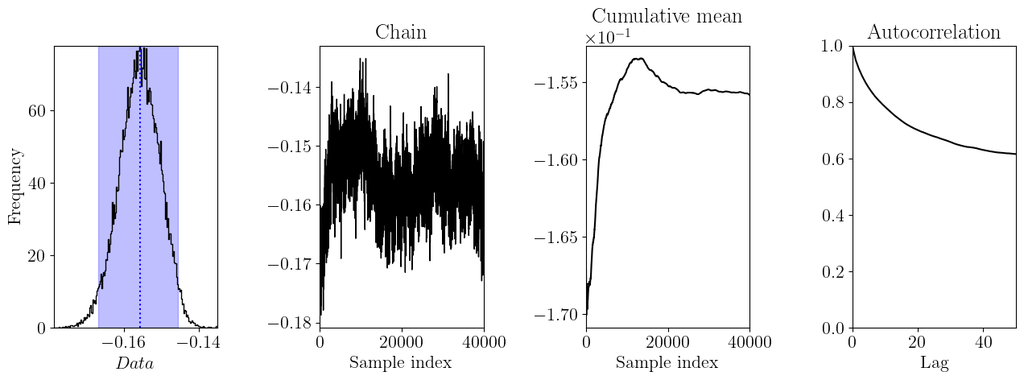

```
(-0.15582087123306043,
 -0.1557405941640726,
 0.005433534498717229,
 array([0.09989177]),
 0.0010502874048943182)
```

```python
accs = np.mean(sampler.acc)*100
print(accs)

Nb = 100000
Nt = 10

samples_burn = samples_1[Nb::Nt,:]
posterior_stats_1D(samples_burn[:,0])
```

### f) Estimating mean and std

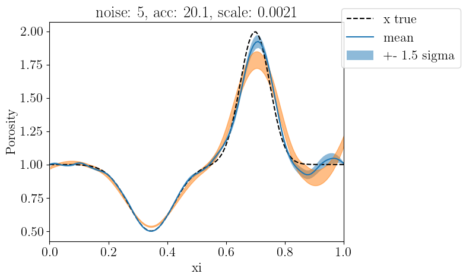

```python
x = np.array([prior.assemble(samples_burn[i,:]) for i in range(np.shape(samples_burn)[0])])

por = np.exp(x)
mu = np.mean(por,axis=0)
std = np.std(por,axis=0)

hdi_data = az.hdi(por,hdi_prob=0.99)

fig,ax = plt.subplots(1)
ax.plot(xi,X_true,'--k',label='x true')
ax.plot(xi,mu,label='mean')
ax.fill_between(xi,mu-1.5*std,mu+1.5*std,alpha=0.5,label='+- 1.5 sigma')
az.plot_hdi(xi,hdi_data.T)
ax.set_xlabel('xi')
ax.set_xlim((0,1))
ax.set_ylabel('Porosity')
ax.set_title(f'noise: {5}, acc: {accs:0.1f}, scale: {scale:0.4f}')
fig.legend(loc='upper center', bbox_to_anchor=(1.05, .95))
```

# 2) Effect of noise level

```python
dvec = [5,10,20,50]
all_samples_2 = np.zeros((Ns+1,N_points,len(dvec)))
accs_2 = []
scales_2 = [0.0021 , 0.0038 , 0.0072 , 0.018]
for i,d in enumerate(dvec):
    print(f'Sampling for noise level of {d} percent')
    y_obs,sigmas = datamodel(noise=d/100)
    log_likelihood = log_likelihood_class(y_obs, sigmas)

    Z0 = np.random.randn(N_KL)
    sampler = pCN(Z0, log_posterior)
    sampler.scale = scales_2[i] #- this sets the step-size in the Metropolis-Hastings method.
    sampler.sample(Ns)
    samples = sampler.get_samples()
    accs_2.append( np.mean(sampler.acc)*100 )
    all_samples_2[:,:,i] = samples
```

```
Sampling for noise level of 5 percent
Sampling for noise level of 10 percent
Sampling for noise level of 20 percent
Sampling for noise level of 50 percent
```

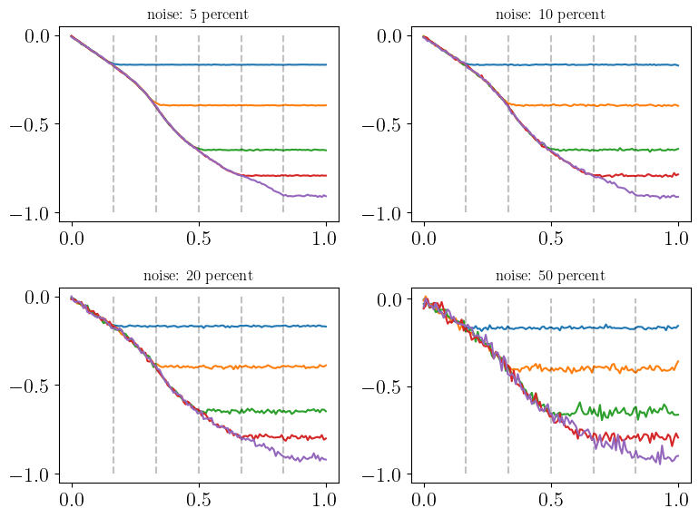

```python
fig,axs = plt.subplots(2,2,figsize=(8,6))
for i,d in enumerate(dvec):
    row,col = divmod(i,2)
    y_obs,sigmas = datamodel(noise=d/100)
    for j in range(5):
        axs[row,col].plot(xi,y_obs[j,:])
        axs[row,col].plot(np.vstack((wells,wells)),np.vstack((np.ones(5)*-1,np.ones(5)*0)),'--k',alpha=0.05)
    axs[row,col].set_title(f'noise: {d} percent',fontsize=12)
fig.tight_layout()
```

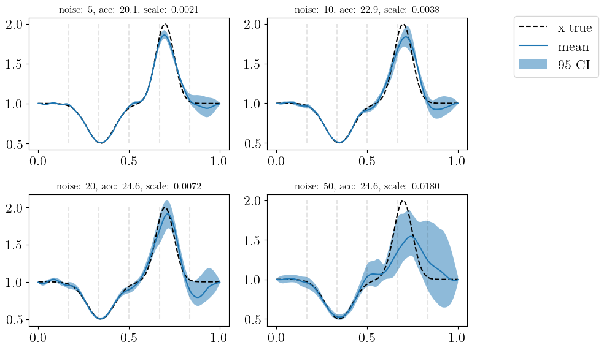

```python
fig,axs = plt.subplots(2,2,figsize=(8,6))
for i,d in enumerate(dvec):
    row,col = divmod(i,2)
    samples = all_samples_2[:,:,i]
    samples_burn = samples[Nb::Nt,:]
    x = np.array([prior.assemble(samples_burn[i,:]) for i in range(np.shape(samples_burn)[0])])
    por = np.exp(x)
    mu = np.mean(por,axis=0)
    low,upp = np.percentile(por,[2.5,97.5],axis=0)
    std = np.std(por,axis=0)

    axs[row,col].plot(xi,X_true,'--k',label='x true')
    axs[row,col].plot(xi,mu,label='mean')
    axs[row,col].fill_between(xi,low,upp,alpha=0.5,label='95 CI')
    axs[row,col].plot(np.vstack((wells,wells)),np.vstack((np.ones(5)*0.5,np.ones(5)*2)),'--k',alpha=0.1)
    axs[row,col].set_title(f'noise: {d}, acc: {accs_2[i]:0.1f}, scale: {scales_2[i]:0.4f}',fontsize=12)

handles, labels = axs[row,col].get_legend_handles_labels()
fig.legend(handles, labels, loc='upper center', bbox_to_anchor=(1.15, .95))
fig.tight_layout()
```

# 3) Broken injectors

```python
y_obs,sigmas = datamodel(noise=5/100)

injectors = np.array([[1 , 2],
                      [1 , 5]])
all_samples_3 = np.zeros((Ns+1,N_points,2))
accs_3 = []
scales_3 = [0.003,0.003]
for i in range(2):
    log_likelihood = log_likelihood_class(y_obs[injectors[i,:]-1,:], sigmas[injectors[i,:]-1])
    log_posterior = lambda Zs: log_likelihood.eval( hydraulic.forward( np.exp( prior.assemble(Zs) ) )[injectors[i,:]-1,:] )
    Z0 = np.random.randn(N_KL)
    sampler = pCN(Z0, log_posterior)
    sampler.scale = scales_3[i] #- this sets the step-size in the Metropolis-Hastings method.

    sampler.sample(Ns)
    samples = sampler.get_samples()

    all_samples_3[:,:,i] = samples
    accs_3.append( np.mean(sampler.acc)*100 )
```

```python
print(accs_3)
```

```
[26.563746872506254, 25.54834890330219]
```

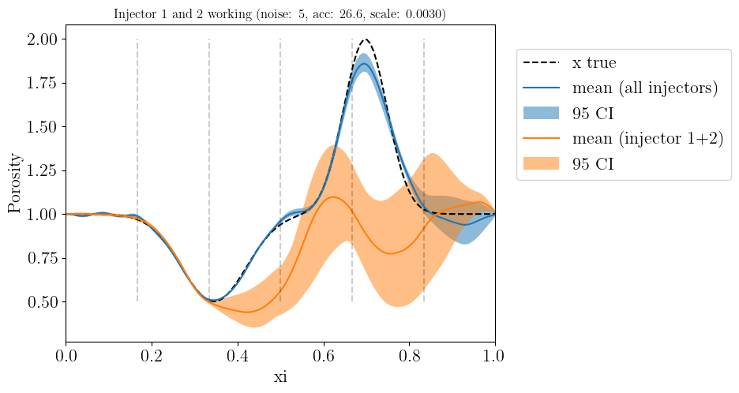

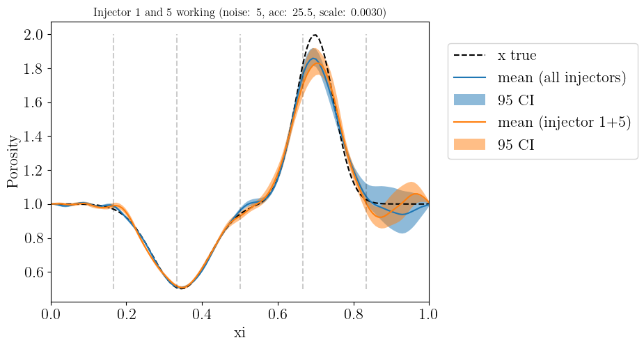

```python
# Injectors 1 and 2
samples_burn = all_samples_3[Nb::Nt,:,0]
x = np.array([prior.assemble(samples_burn[i,:]) for i in range(np.shape(samples_burn)[0])])
por = np.exp(x)
mu0 = np.mean(por,axis=0)
low0,upp0 = np.percentile(por,[2.5,97.5],axis=0)

# Injectors 1 and 5
samples_burn = all_samples_3[Nb::Nt,:,1]
x = np.array([prior.assemble(samples_burn[i,:]) for i in range(np.shape(samples_burn)[0])])
por = np.exp(x)
mu1 = np.mean(por,axis=0)
low1,upp1 = np.percentile(por,[2.5,97.5],axis=0)

# Comparison
samples_burn = all_samples_2[Nb::Nt,:,0]
x = np.array([prior.assemble(samples_burn[i,:]) for i in range(np.shape(samples_burn)[0])])
por = np.exp(x)
mu2 = np.mean(por,axis=0)
low2,upp2 = np.percentile(por,[2.5,97.5],axis=0)


fig,ax = plt.subplots(1,1)
ax.plot(xi,X_true,'--k',label='x true')
ax.plot(xi,mu2,label='mean (all injectors)')
ax.fill_between(xi,low2,upp2,alpha=0.5,label='95 CI ')
ax.plot(xi,mu0,label='mean (injector 1+2)')
ax.fill_between(xi,low0,upp0,alpha=0.5,label='95 CI')
ax.plot(np.vstack((wells,wells)),np.vstack((np.ones(5)*0.5,np.ones(5)*2)),'--k',alpha=0.2)
fig.tight_layout()
ax.set_xlabel('xi')
ax.set_xlim((0,1))
ax.set_ylabel('Porosity')
ax.set_title(f'Injector 1 and 2 working (noise: {5}, acc: {accs_3[0]:0.1f}, scale: {scales_3[0]:0.4f})',fontsize=12)
ax.legend(loc='upper center', bbox_to_anchor=(1.3, .95))


fig,ax = plt.subplots(1,1)
ax.plot(xi,X_true,'--k',label='x true')
ax.plot(xi,mu2,label='mean (all injectors)')
ax.fill_between(xi,low2,upp2,alpha=0.5,label='95 CI')
ax.plot(xi,mu1,label='mean (injector 1+5)')
ax.fill_between(xi,low1,upp1,alpha=0.5,label='95 CI')
ax.plot(np.vstack((wells,wells)),np.vstack((np.ones(5)*0.5,np.ones(5)*2)),'--k',alpha=0.2)
fig.tight_layout()
ax.set_xlabel('xi')
ax.set_xlim((0,1))
ax.set_ylabel('Porosity')
ax.set_title(f'Injector 1 and 5 working (noise: {5}, acc: {accs_3[1]:0.1f}, scale: {scales_3[1]:0.4f})',fontsize=12)
ax.legend(loc='upper center', bbox_to_anchor=(1.3, .95))
```

# 4) Broken sensors

```python
idx = np.vstack((np.arange(0,int(N_points/2)), np.arange(int(N_points/2),int(N_points))))

def log_posterior_broken_sensors(Zs,idx):
    sensors = hydraulic.forward( np.exp( prior.assemble(Zs) ) )
    return log_likelihood.eval( sensors[:,idx] )
```

```python
y_obs,sigmas = datamodel(noise=5/100)
all_samples_4 = np.zeros((Ns+1,N_points,2))
accs_4 = []
scales_4 = [0.003,0.002]
for i in range(2):
    log_likelihood = log_likelihood_class(y_obs[:,idx[i]], sigmas)

    Z0 = np.random.randn(N_KL)
    log_posterior = lambda Zs : log_posterior_broken_sensors(Zs,idx=idx[i])
    sampler = pCN(Z0, log_posterior)
    sampler.scale = scales_4[i] #- this sets the step-size in the Metropolis-Hastings method.

    sampler.sample(Ns)
    samples = sampler.get_samples()

    all_samples_4[:,:,i] = samples
    accs_4.append( np.mean(sampler.acc)*100 )
```

```python
print(accs_4)
```

```
[29.695140609718777, 27.338745322509357]
```

[figure not shown]

[figure not shown]

```python
# First half working
samples_burn = all_samples_4[Nb::Nt,:,0]
x = np.array([prior.assemble(samples_burn[i,:]) for i in range(np.shape(samples_burn)[0])])
por = np.exp(x)
mu0 = np.mean(por,axis=0)
low0,upp0 = np.percentile(por,[2.5,97.5],axis=0)

# Second half working
samples_burn = all_samples_4[Nb::Nt,:,1]
x = np.array([prior.assemble(samples_burn[i,:]) for i in range(np.shape(samples_burn)[0])])
por = np.exp(x)
mu1 = np.mean(por,axis=0)
low1,upp1 = np.percentile(por,[2.5,97.5],axis=0)

# Comparison
samples_burn = all_samples_2[Nb::Nt,:,0]
x = np.array([prior.assemble(samples_burn[i,:]) for i in range(np.shape(samples_burn)[0])])
por = np.exp(x)
mu2 = np.mean(por,axis=0)
low2,upp2 = np.percentile(por,[2.5,97.5],axis=0)


fig,ax = plt.subplots(1,1)
ax.plot(xi,X_true,'--k',label='x true')
ax.plot(xi,mu2,label='mean (all sensors)')
ax.fill_between(xi,low2,upp2,alpha=0.5,label='95 CI')
ax.plot(xi,mu0,label='mean (first half)')
ax.fill_between(xi,low0,upp0,alpha=0.5,label='95 CI')
fig.tight_layout()
ax.set_xlabel('xi')
ax.set_xlim((0,1))
ax.set_ylabel('Porosity')
ax.set_title(f'First half of sensors working (noise: {d}, acc: {accs_4[0]:0.1f}, scale: {scales_4[0]:0.4f})',fontsize=12)
ax.legend(loc='upper center', bbox_to_anchor=(1.15, .95))


fig,ax = plt.subplots(1,1)
ax.plot(xi,X_true,'--k',label='x true')
ax.plot(xi,mu2,label='mean (all sensors)')
ax.fill_between(xi,low2,upp2,alpha=0.5,label='95 CI')
ax.plot(xi,mu1,label='mean (second half)')
ax.fill_between(xi,low1,upp1,alpha=0.5,label='95 CI')
fig.tight_layout()
ax.set_xlabel('xi')
ax.set_xlim((0,1))
ax.set_ylabel('Porosity')
ax.set_title(f'Second half of sensors working (noise: {d}, acc: {accs_4[1]:0.1f}, scale: {scales_4[1]:0.4f})',fontsize=12)
ax.legend(loc='upper center', bbox_to_anchor=(1.15, .95))
```